```python
import pandas as pd
import matplotlib.pyplot as plt
import seaborn as sns
from scipy import stats
```

```python
sportasi = pd.read_excel ("sportasi_zscore.xlsx")
```

# Učitavamo opet dataset sportasi

## Ovaj put ćemo se fokusirati na otkrivanje i rješavanje problema outliera u varijabli Height.

```python
sportasi.head()
```

|  | Age | Height |
| --- | --- | --- |
| 0 | 41 | 185 |
| 1 | 29 | 180 |
| 2 | 34 | 175 |
| 3 | 48 | 160 |
| 4 | 32 | 192 |

```python
sportasi.describe()
```

|  | Age | Height |
| --- | --- | --- |
| count | 199.000000 | 199.000000 |
| mean | 41.206030 | 186.417085 |
| std | 15.411289 | 10.077072 |
| min | -27.000000 | 150.000000 |
| 25% | 32.000000 | 181.000000 |
| 50% | 41.000000 | 187.000000 |
| 75% | 51.000000 | 192.000000 |
| max | 147.000000 | 228.000000 |

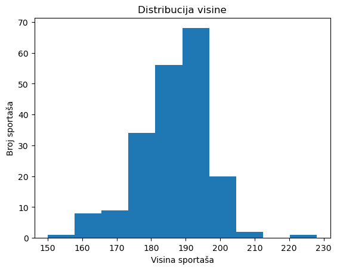

```python
plt.hist (sportasi.Height)
plt.xlabel ("Visina sportaša")
plt.ylabel ("Broj sportaša")
plt.title ("Distribucija visine")
```

```python
sportasi4 = sportasi.copy()
```

## Ponovo radimo kopiju originalnog dataseta. Radimo je kako bismo i dalje imali originalne podatke ako nešto pogriješimo ili želimo isporabti neku novu metodu.

```python
sportasi4.sort_values (by = ["Height"])
```

|  | Age | Height |
| --- | --- | --- |
| 118 | 46 | 150 |
| 60 | 62 | 159 |
| 3 | 48 | 160 |
| 161 | 45 | 160 |
| 21 | 37 | 163 |
| ... | ... | ... |
| 52 | 41 | 203 |
| 77 | 47 | 204 |
| 188 | 62 | 205 |
| 72 | 57 | 206 |
| 168 | 39 | 228 |

199 rows × 2 columns

## Za razliku od prošlog primjera gdje smo outliere mogli odmah prepoznati, jer su bili logični, ovdje se nalazimo u situaciji da nismo sigurni koji podaci su outlieri

## Treba nam metoda koja bi nam pouzdano rekla, na znanstvenoj osnovi koji podatak je outlier u skupu, koji odskače od populacije u kojoj se nalazi

## Pitanje glasi: koji su podaci outlieri?

### Je li visina od 228 outlier? A što je s visinom od 206? A 205?

### S druge strane, je li visina od 150 također outlier?

## Ne želite da se takve odluke donose na osnovi osjećaja

## Još je i jednostavno kad su podaci o nečemu o čemu imate znanja. Što da se umjesto varijable visina radi o razini hemoglobina u krvi? Koji podatak je sumnjiv, možda pogrešan? Ili neko drugo područje s kojim niste upoznati

```python
sportasi4["zscore"] = stats.zscore(sportasi4["Height"])
```

# Korištenje metode Zscore

## Vučemo je iz librarya stats i stvaramo novu varijablu koju računamo na osnovi varijable Height

```python
sportasi4.head(10)
```

|  | Age | Height | zscore |
| --- | --- | --- | --- |
| 0 | 41 | 185 | -0.140979 |
| 1 | 29 | 180 | -0.638407 |
| 2 | 34 | 175 | -1.135834 |
| 3 | 48 | 160 | -2.628116 |
| 4 | 32 | 192 | 0.555419 |
| 5 | 31 | 195 | 0.853875 |
| 6 | 45 | 191 | 0.455933 |
| 7 | 46 | 180 | -0.638407 |
| 8 | 62 | 181 | -0.538921 |
| 9 | 33 | 179 | -0.737892 |

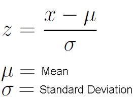

## Za svaku pojedinu vrijednost visine (ovdje je to x) računamo zscore korištenjem ove formule

## Nulti redak, visina iznosi 185, prosjek iznosi 186,41, a standardna devijacija iznosi 10,07

```python
sportasi4.sort_values (by = ["zscore"])
```

|  | Age | Height | zscore |
| --- | --- | --- | --- |
| 118 | 46 | 150 | -3.622970 |
| 60 | 62 | 159 | -2.727601 |
| 3 | 48 | 160 | -2.628116 |
| 161 | 45 | 160 | -2.628116 |
| 21 | 37 | 163 | -2.329659 |
| ... | ... | ... | ... |
| 52 | 41 | 203 | 1.649759 |
| 77 | 47 | 204 | 1.749244 |
| 188 | 62 | 205 | 1.848730 |
| 72 | 57 | 206 | 1.948215 |
| 168 | 39 | 228 | 4.136895 |

199 rows × 3 columns

```python
threshold = 3
```

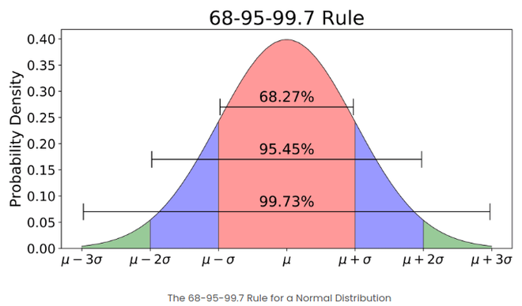

## Zscore metoda se koristi na način da svaka varijabla (ovdje visina) čija je vrijednost zscorea veća od plus ili minus 3 se smatra outlierom

## Statistički dokazano pravilo da u normalno distribuiranim podacima 99,73 posto podataka ima zscore između plus i minus 3.

## Mogućnost greške iznosi 0,27 %

## Varijable koje imaju vrijednost z-scorea veću od +/- 3 se mogu maknuti ili popraviti

```python
outliers = sportasi4[sportasi4['zscore'].abs() > threshold]['Height'].tolist()
```

```python
outliers
```

```
[150, 228]
```

## Identificirali smo vrijednosti outliera koji su pohranjeni u listu.

## Pazi: u prošlom primjeru smo ručno pohranili vrijednosti outliera u listu i to njihove indexe, ovdje to ne radimo

## Ovo napominjemo zbog manjih razlika u kodu koji dolazi

```python
mean_without_outliers = sportasi4[sportasi4['zscore'].abs() <= threshold]['Height'].mean()
```

```python
mean_without_outliers
```

```
186.39086294416245
```

## Računamo prosjek varijable Visina, ali bez outliera te je ispisujemo

```python
sportasi4.loc[sportasi4['Height'].isin(outliers), 'Height'] = mean_without_outliers
```

```python
sportasi4.head()
```

|  | Age | Height | zscore |
| --- | --- | --- | --- |
| 0 | 41 | 185.0 | -0.140979 |
| 1 | 29 | 180.0 | -0.638407 |
| 2 | 34 | 175.0 | -1.135834 |
| 3 | 48 | 160.0 | -2.628116 |
| 4 | 32 | 192.0 | 0.555419 |

```python
sportasi4.describe()
```

|  | Age | Height | zscore |
| --- | --- | --- | --- |
| count | 199.000000 | 199.000000 | 1.990000e+02 |
| mean | 41.206030 | 186.390863 | 3.838359e-16 |
| std | 15.411289 | 9.279853 | 1.002522e+00 |
| min | -27.000000 | 159.000000 | -3.622970e+00 |
| 25% | 32.000000 | 181.000000 | -5.389212e-01 |
| 50% | 41.000000 | 187.000000 | 5.799152e-02 |
| 75% | 51.000000 | 192.000000 | 5.554188e-01 |
| max | 147.000000 | 206.000000 | 4.136895e+00 |

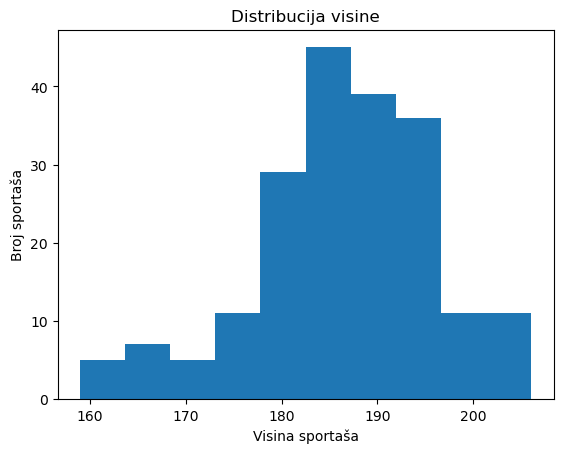

```python
plt.hist (sportasi4.Height)
plt.xlabel ("Visina sportaša")
plt.ylabel ("Broj sportaša")
plt.title ("Distribucija visine")
```

# **Zadatak1**

## Učitajte dataset kolaci.xlsx i provjerite ima li u njemu outliera

## Za vašu predikciju poslovanja vaše slastičarne tokom turističke sezone, bilo bi lijepo da imate čiste podatke.

```python
kolaci = pd.read_excel ("kolaci.xlsx")
```

```python
kolaci.head()
```

|  | tezina |
| --- | --- |
| 0 | 62 |
| 1 | 92 |
| 2 | 84 |
| 3 | 98 |
| 4 | 82 |

```python
kolaci.describe()
```

|  | tezina |
| --- | --- |
| count | 150.000000 |
| mean | 99.773333 |
| std | 11.207707 |
| min | 37.000000 |
| 25% | 93.000000 |
| 50% | 100.000000 |
| 75% | 107.000000 |
| max | 140.000000 |

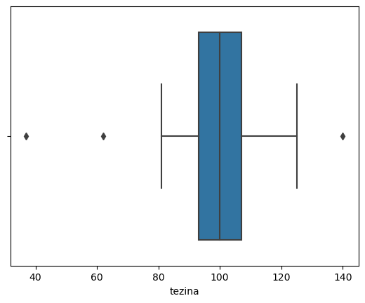

```python
sns.boxplot (x = kolaci["tezina"])
```